# Mixed-Effects Models

Random Intercepts and Random Slopes

Part Three: Random intercepts vs. Random intercepts and slopes models

**Sleep Example**

Bates et al. “Fitting Linear Mixed-Effects Models Using lme4” https://cran.r-project.org/web/packages/lme4/vignettes/lmer.pdf

Average reaction time (ms) per day for subjects in a sleep deprivation study (Belenky et al.2003). On day 0 the subjects had their normal amount of sleep. Starting that night they were restricted to three hours of sleep per night for nine days. Their reaction time was tested on each day.

[figure not shown]

F1 driver taking reaction time test.

```r
sleepstudy
```

```
##     Reaction Days Subject
## 1   249.5600    0     308
## 2   258.7047    1     308
## 3   250.8006    2     308
## 4   321.4398    3     308
## 5   356.8519    4     308
## 6   414.6901    5     308
## 7   382.2038    6     308
## 8   290.1486    7     308
## 9   430.5853    8     308
## 10  466.3535    9     308
## 11  222.7339    0     309
## 12  205.2658    1     309
## 13  202.9778    2     309
## 14  204.7070    3     309
```

[output cut: 166 more lines]

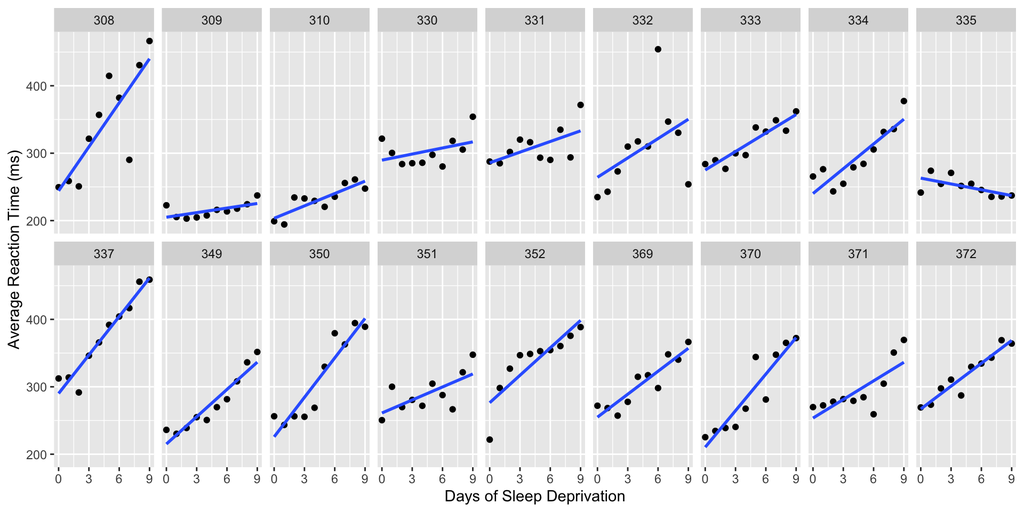

```r
ggplot(data=sleepstudy, aes(Days, Reaction)) +
  geom_point() +
  stat_smooth(method="lm", se=FALSE) +
  facet_wrap(.~Subject, nrow = 2) +
  xlab("Days of Sleep Deprivation") +
  ylab("Average Reaction Time (ms)") +
  scale_x_continuous(breaks=seq(0, 9, 3))  # Ticks from 0-9, every 3
```

We have a few different ways to fit a model that accounts for the variation among participants in the study, who were a random selection of people.

```r
fm1 <- lmer(Reaction ~ Days + (Days | Subject), data=sleepstudy) # random intercepts and random slopes model
fm2 <- lmer(Reaction ~ Days + (1 | Subject), data=sleepstudy) #random intercepts, same slopes
```

fm1 is considered a random slopes and random intercepts model because of the way the random effects are specified. This allows each subject to have a unique starting level (intercept) and a unique rate of change (slope) across days, with the variability estimated directly from the data.

**1. Fixed Effects Portion**

The term `Reaction ~ Days` specifies that the average (population-level) relationship between `Days` and `Reaction` will be estimated. This is the fixed effect part: a single overall intercept and a single overall slope for `Days` that apply across all subjects.

**2. Random Effects Portion `(Days | Subject)`**

This part tells `lme4` that both the intercept and the slope for `Days` should be allowed to vary by `Subject`.

The | symbol means “grouping by”.

`Days | Subject` expands internally to two separate random effect terms:

- `(1 | Subject)` → a random intercept for each subject.
- `(0 + Days | Subject)` → a random slope for the effect of `Days` for each subject.

**3. Visualization**

If you plotted each subject’s regression line:

**Random intercepts only:** All lines are parallel but vertically shifted.

**Random slopes only:** All lines intersect at the same point but fan out at different angles. (not commonly used in ecological models)

**Random intercepts and slopes:** Lines can vary in both height and tilt, looking like a messy “spaghetti plot”.

```r
summary(fm1)
```

```
## Linear mixed model fit by REML. t-tests use Satterthwaite's method [
## lmerModLmerTest]
## Formula: Reaction ~ Days + (Days | Subject)
##    Data: sleepstudy
##
## REML criterion at convergence: 1743.6
##
## Scaled residuals:
##     Min      1Q  Median      3Q     Max
## -3.9536 -0.4634  0.0231  0.4634  5.1793
##
## Random effects:
##  Groups   Name        Variance Std.Dev. Corr
##  Subject  (Intercept) 612.10   24.741
##           Days         35.07    5.922   0.07
##  Residual             654.94   25.592
## Number of obs: 180, groups:  Subject, 18
##
## Fixed effects:
##             Estimate Std. Error      df t value Pr(>|t|)
## (Intercept)  251.405      6.825  17.000  36.838  < 2e-16 ***
## Days          10.467      1.546  17.000   6.771 3.26e-06 ***
## ---
## Signif. codes:  0 '***' 0.001 '**' 0.01 '*' 0.05 '.' 0.1 ' ' 1
##
## Correlation of Fixed Effects:
##      (Intr)
## Days -0.138
```

```r
summary(fm2)
```

```
## Linear mixed model fit by REML. t-tests use Satterthwaite's method [
## lmerModLmerTest]
## Formula: Reaction ~ Days + (1 | Subject)
##    Data: sleepstudy
##
## REML criterion at convergence: 1786.5
##
## Scaled residuals:
##     Min      1Q  Median      3Q     Max
## -3.2257 -0.5529  0.0109  0.5188  4.2506
##
## Random effects:
##  Groups   Name        Variance Std.Dev.
##  Subject  (Intercept) 1378.2   37.12
##  Residual              960.5   30.99
## Number of obs: 180, groups:  Subject, 18
##
## Fixed effects:
##             Estimate Std. Error       df t value Pr(>|t|)
## (Intercept) 251.4051     9.7467  22.8102   25.79   <2e-16 ***
## Days         10.4673     0.8042 161.0000   13.02   <2e-16 ***
## ---
## Signif. codes:  0 '***' 0.001 '**' 0.01 '*' 0.05 '.' 0.1 ' ' 1
##
## Correlation of Fixed Effects:
##      (Intr)
## Days -0.371
```

Here the df column represents the *approximate* degrees of freedom left over for testing each fixed effect. It is adjusted downward for hierarchical structure and estimation of random effects. A different df is computed for each fixed effect, depending on how much information is available for that predictor.

Interpretation: **The df reported are leftover, not used**. They represent how much information remains to estimate variability around that particular fixed effect.

Analogy: Think of df as a “budget of information”. Fixed effects and random effects estimation “spend” some of this budget. What’s left over is reported in `summary()` for each fixed effect. The df reported are like the balance remaining in your account, not the total amount you’ve already spent. (see the handout in the “resources” folder in this repository for more detailed information)

We are probably not intrinsically interested in comparing the different individuals that participated in the study, but its good to visualize how individuals (random effect) contribute to the fixed effect (Days). The fixed effect regression line is essentially an average of the random effects (individuals). Because the data do not change when fitting models with different random effects (only the models change), the fixed effects are the same among models with differently specified random effects.

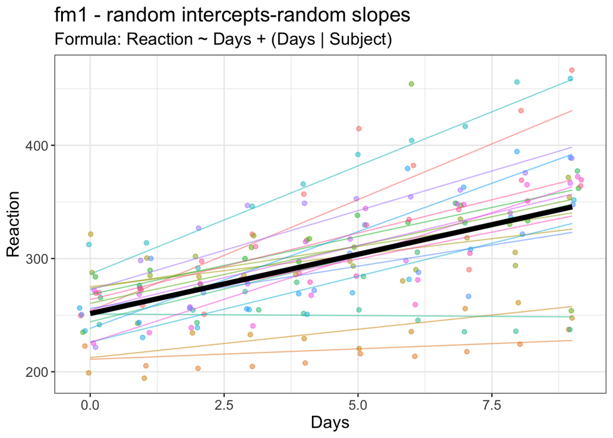

```r
flexplot::visualize(fm1, plot="model", sample=18) + #use all 18 of the measured individuals
  ggtitle("fm1 - random intercepts-random slopes") +
  labs(subtitle = "Formula: Reaction ~ Days + (Days | Subject)")
```

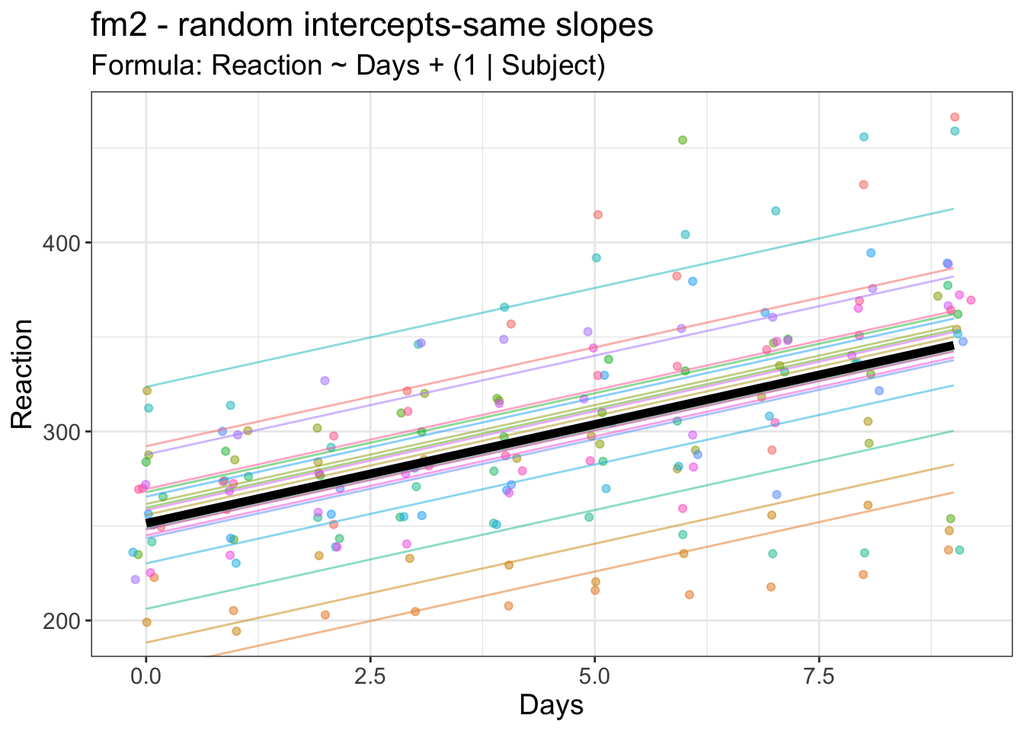

```r
flexplot::visualize(fm2, plot="model", sample=18) +
  ggtitle("fm2 - random intercepts-same slopes") +
  labs(subtitle = "Formula: Reaction ~ Days + (1 | Subject)")
```

But notice that the fixed effects (the black line) is identical between the two models. Its only the random effects (study participants [Subjects]) that differ.

Compare model summaries for fm1 and fm2 to see identical intercepts and slopes for the fixed effects.

```r
arm::display(fm1)
```

```
## lmer(formula = Reaction ~ Days + (Days | Subject), data = sleepstudy)
##             coef.est coef.se
## (Intercept) 251.41     6.82
## Days         10.47     1.55
##
## Error terms:
##  Groups   Name        Std.Dev. Corr
##  Subject  (Intercept) 24.74
##           Days         5.92    0.07
##  Residual             25.59
## ---
## number of obs: 180, groups: Subject, 18
## AIC = 1755.6, DIC = 1760.3
## deviance = 1751.9
```

```r
arm::display(fm2)
```

```
## lmer(formula = Reaction ~ Days + (1 | Subject), data = sleepstudy)
##             coef.est coef.se
## (Intercept) 251.41     9.75
## Days         10.47     0.80
##
## Error terms:
##  Groups   Name        Std.Dev.
##  Subject  (Intercept) 37.12
##  Residual             30.99
## ---
## number of obs: 180, groups: Subject, 18
## AIC = 1794.5, DIC = 1801.7
## deviance = 1794.1
```

Note that is is only the standard errors that differ in the fixed effects. The `paramaters` package has a function for abbreviated comparison of coefficients.

```r
#parameters::compare_parameters(fm1, fm2)
result <- parameters::compare_parameters(fm1, fm2, select = "{estimate}<br>({se})|{p}")
print_html(result)
```

| Parameter | fm1 Coefficient(SE) | fm1 p | fm2 Coefficient(SE) | fm2 p |
| --- | --- | --- | --- | --- |
| (Intercept) | 251.41 (6.82) | <0.001 | 251.41 (9.75) | <0.001 |
| Days | 10.47 (1.55) | <0.001 | 10.47 (0.80) | <0.001 |
| Observations | 180 |  | 180 |  |

```r
performance::compare_performance(fm1, fm2)
```

```
## # Comparison of Model Performance Indices
##
## Name |           Model |  AIC (weights) | AICc (weights) |  BIC (weights)
## -------------------------------------------------------------------------
## fm1  | lmerModLmerTest | 1764.0 (>.999) | 1764.5 (>.999) | 1783.1 (>.999)
## fm2  | lmerModLmerTest | 1802.1 (<.001) | 1802.3 (<.001) | 1814.9 (<.001)
##
## Name | R2 (cond.) | R2 (marg.) |   ICC |   RMSE |  Sigma
## --------------------------------------------------------
## fm1  |      0.799 |      0.279 | 0.722 | 23.438 | 25.592
## fm2  |      0.704 |      0.280 | 0.589 | 29.411 | 30.991
```

Both models were statistically significant in their fixed effects (`Days`), and this was primarily what we were interested in.

In this case the more complex model (which costs more degrees of freedom to estimate model parameters) did a better job explaining the variation by removing random effects of individuals. The more complex model removed random effects of individuals by fitting a different intercept **and** different slope for each individual.

As is often the case with complex models, we are not concerned only with statistical significance of our factor of interest (e.g. `Days`) but also by the overall explanatory power of the model. We will use this framework in our upcoming discussion of model selection.